# CS 422: Homework #5

Tiffany Wong, Illinois Institute of Technology

# 2.1 Exploratory data analysis on the Hotels Bookings dataset.

## (a) How many observations exist in the dataset for hotel type H1 and hotel type H2? Use R commands to paste0 the frequency of the hotel types. (Hint: Do not write a loop, one R command will do this.)

```r
# Set working directory as needed
setwd("/Users/tiffwong/Desktop/cs422/hw/hw 5/")

df <- read.csv("hotel_bookings.csv")
paste("H1:", sum(df$hotel == "Resort Hotel"))
```

```
[1] "H1: 40060"
```

```r
paste("H2:", sum(df$hotel == "City Hotel"))
```

```
[1] "H2: 79330"
```

## (b) What is the distribution of the class label in the dataset? Your output should look like the following:

Number of guests who canceled reservation: XXXX Number of guests who did not cancel the reservation: XXXX

```r
paste0("Number of guests who canceled reservation:  ", sum(df$is_canceled == 1))
```

```
[1] "Number of guests who canceled reservation:  44224"
```

```r
paste0("Number of guests who did not cancel the reservation: ", sum(df$is_canceled == 0))
```

```
[1] "Number of guests who did not cancel the reservation: 75166"
```

## (c) Which customer has the most reservations? Your output should look like the following:

Customer type with the most reservations is XXXX, with YYYY reservations (Hint: Use the command from (a), and play around with which.max(), and use cat() and paste() to create the above output string).

```r
freq_table <- table(df$customer_type)
index <- which.max(freq_table)
most_frequent_value <- freq_table[index]
most_frequent_type <- names(freq_table)[index]
paste0("Customer type with the most reservations is ", most_frequent_type, ", with ", most_frequent_value, " reservations")
```

```
[1] "Customer type with the most reservations is Transient, with 89613 reservations"
```

## (d) What was the most number of parking spaces required by customers? And how many customers requested that many parking spaces? Your output should look like the following, where XXXX is the number of customers and YYYY is the number of parking spaces:

XXXX customers required the most number of parking spaces (YYYY). (Hint: Use the same hint from (c)).

```r
max_spaces <- df$required_car_parking_spaces[which.max(df$required_car_parking_spaces)]
customers <- sum(df$required_car_parking_spaces == max_spaces)
paste0(customers, " customers required the most number of parking spaces (", max_spaces, ").")
```

```
[1] "2 customers required the most number of parking spaces (8)."
```

## (e) What was the least number of parking spaces required by customers? And how many customers requested that many parking spaces? Your output should look like the following, where XXXX is the number of customers and YYYY is the number of parking spaces:

XXXX customers required the least number of parking spaces (YYYY). (Hint: Use the same hint from (c)).

```r
min_spaces <- df$required_car_parking_spaces[which.min(df$required_car_parking_spaces)]
customers <- sum(df$required_car_parking_spaces == min_spaces)
paste0(customers, " customers required the least number of parking spaces (", min_spaces, ").")
```

```
[1] "111974 customers required the least number of parking spaces (0)."
```

## (f) How many people who expressed a preference for a particular room type during reservation were actually assigned that specific room type? Your output should look like the following:

XX.XX% of the people who expressed a room preference during reservation got the room during check-in.

```r
percentage <- sum(as.vector(df$reserved_room_type) == as.vector(df$assigned_room_type)) * 100 / nrow(df)
paste0(round(percentage, 2), "% of the people who expressed a room preference during reservation got the rooms during check-in.")
```

```
[1] "87.51% of the people who expressed a room preference during reservation got the rooms during check-in."
```

## (g) Order the dataset between city hotels and resort hotels. For each type of hotel, find the top 10 countries of origin that attract the most bookings. Plot a bar plot for each hotel type that contains the country of origin. Make sure you use colors for each bin and title each plot accordingly. The x-axis of the barplot should contain the 3- (or 2-) letter code for the country. At the very least, your graphical output should look like the following, but try to make it as attractive as possible.

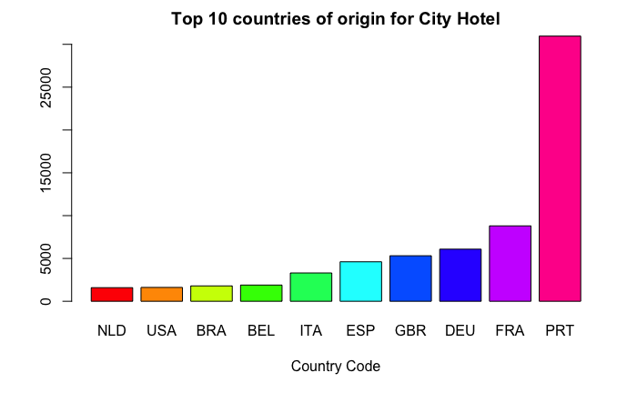

```r
raw_city_hotels <- df[df$hotel == "City Hotel", ]
city_hotels <- raw_city_hotels[!(raw_city_hotels$country == "NULL"),]
freq_country <- table(city_hotels$country)
countries <- tail(sort(freq_country), 10)
raw_frequencies <- as.vector(countries)
country_codes <- names(countries)
barplot(raw_frequencies, main="Top 10 countries of origin for City Hotel", xlab="Country Code", names.arg=country_codes, col = rainbow(10))
```

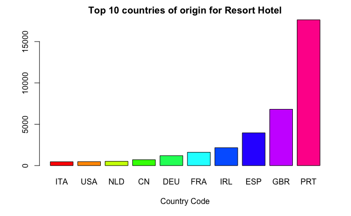

```r
raw_resort_hotels <- df[df$hotel == "Resort Hotel", ]
resort_hotels <- raw_resort_hotels[!(raw_resort_hotels$country == "NULL"),]
freq_country_resort <- table(resort_hotels$country)
countries_resort <- tail(sort(freq_country_resort), 10)
raw_frequencies_resort <- as.vector(countries_resort)
country_codes_resort <- names(countries_resort)
barplot(raw_frequencies_resort, main="Top 10 countries of origin for Resort Hotel", xlab="Country Code", names.arg=country_codes_resort, col = rainbow(10))
```

## (h) You will note that the most visitors to either type of the hotels arrive from a specific country.

### h(i) paste0 the name of this country.

paste0(“The country with the most visitors to either type of hotel is: Portugal (PRT).”)

### h(ii) What can you say about the origin of the dataset based on (i)?

Based on my answer for (i), the origin of of the dataset could be in Portugal because that would mean more of the domestic customers are flying more frequent.

# 2.2 Decision Tree

## (a) Create the best decision tree model that you can to predict whether a booking will be canceled or not. You may use as many (or as least) number of predictor variables, it is up to you. Hint: Think!

```r
library(rpart)
library(rpart.plot)
```

### a(i) Plot the decision tree.

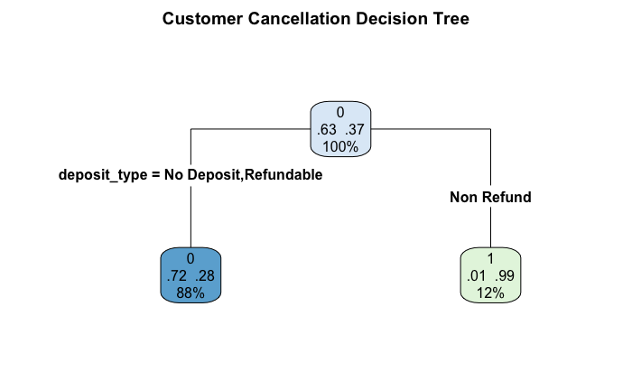

```r
set.seed(1122)
index <- sample(1:nrow(df), 0.90*dim(df)[1])
train.df <- df[index, ]
test.df <- df[-index, ]

model <- rpart(is_canceled ~ deposit_type + customer_type + is_repeated_guest + days_in_waiting_list, data = train.df, method = "class")
rpart.plot(model, extra = 104, fallen.leaves = T, type = 4, main = "Customer Cancellation Decision Tree")
```

### a(iii) Fit the model on the held out test dataset, and from the resulting confusion matrix, paste0 the following attributes: Accuracy, Error, Balanced Accuracy, Specificity, Sensitivity, and Precision.

```r
pred <- predict(model, test.df, type="class")
confusion_matrix <- table(pred, test.df$is_canceled)
true_negative <- confusion_matrix[1, 1]
true_positive <- confusion_matrix[2, 2]
false_negative <- confusion_matrix[1, 2]
false_positive <- confusion_matrix[2, 1]

accuracy <- round(((true_negative + true_positive)/(true_negative + true_positive + false_negative + false_positive)), digits = 3)
error <- round(((false_negative + false_positive)/(true_negative + true_positive + false_negative + false_positive)), digits = 3)
specificity <- round(((true_negative)/(true_negative + false_positive)), digits = 3)
sensitivity <- round(((true_positive)/(true_positive + false_negative)), digits = 3)
precision <- round(((true_positive)/(true_positive + false_positive)), digits = 3)
balanced_accuracy <- round(((sensitivity + specificity)/2), digits = 3)
paste0("Accuracy: ", accuracy)
```

```
[1] "Accuracy: 0.748"
```

```r
paste0("Error: ", error)
```

```
[1] "Error: 0.252"
```

```r
paste0("Balanced Accuracy: ", balanced_accuracy)
```

```
[1] "Balanced Accuracy: 0.663"
```

```r
paste0("Specificity: ", specificity)
```

```
[1] "Specificity: 0.998"
```

```r
paste0("Sensitivity: ", sensitivity)
```

```
[1] "Sensitivity: 0.328"
```

```r
paste0("Precision: ", precision)
```

```
[1] "Precision: 0.989"
```

### a(iv) Plot a ROC curve on your held out test dataset. (Make sure you use library(ROCR) to use the ROC-specific APIs.)

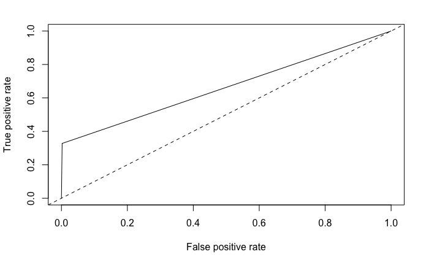

```r
library(ROCR)

pred <- predict(model, test.df, type="prob")
pred_post <- prediction(pred[, 2], test.df$is_canceled)
plot(performance(pred_post, "tpr", "fpr"))
abline(0, 1, lty = 2)
```

### a(v) What is the AUC of the ROC curve.

```r
paste0("AUC:", as.numeric(performance(pred_post, "auc")@y.values))
```

```
[1] "AUC:0.662862934165231"
```